RritmoForceCurveJump to app readings

OAR SENSOR · LEVEL-FLOOR CHECK

# Level the oar. Then align the sensor.

Rest the oar on a level floor with the blade face-up. Support the sleeve and shaft so the entire oar is level before checking AccY and AccZ.

**Alignment target**AccY and AccZ each between −0.02 g and +0.02 g

[figure not shown]

Overview: blade face-up, oar supported and level

SET THE OAR ON THE FLOOR

## The supports make the reference truly level.

Keep the oar motionless in the supported floor position while checking the sensor readings.

1

### Blade face-up

Place the oar on a **level floor** with the broad face of the blade pointing straight up.

2

### Level the sleeve

Place wood beneath the sleeve so its **flat back is parallel to the floor**. This sets the rotational reference.

3

### Level the shaft

Use the second wood piece toward the blade end so the shaft’s **longitudinal direction is level** with the floor.

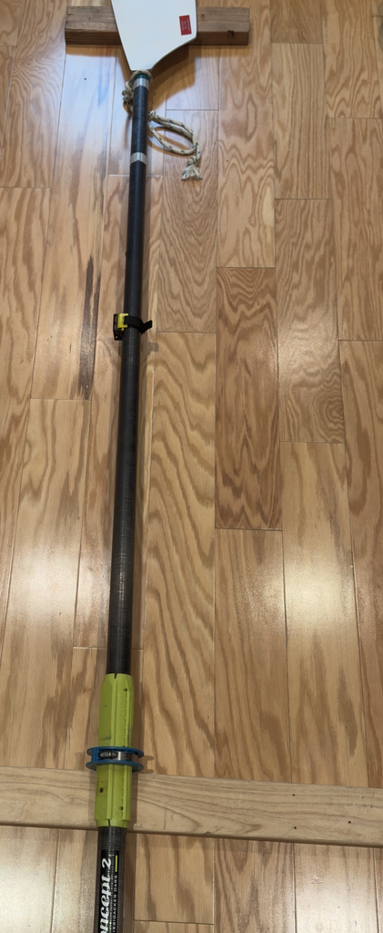

123

PHOTO KEY

## Check all three markers.

1

**Blade face-up**

The broad face of the blade points straight up.

2

**Blade-side support**

This support prevents the shaft from sloping along its length.

3

**Sleeve support**

This support keeps the sleeve’s flat surface parallel to the floor.

SENSOR Y-AXIS DIRECTION

## Point the sensor the correct way along the oar.

The sensor button is offset within the cage bracket opening. Install the sensor so that offset button sits **closer to the blade end of the oar**.

- Button offset points toward the blade
- Bracket is snug and cannot rotate
- Sensor face remains visible through the cage

This direction sets the sensor’s Y-axis orientation. It is separate from the level-floor calibration position.

[figure not shown]

1

← BLADE END**1** Button offset is on the blade side

WITMOTION · MAIN SCREEN

## Adjust until both readings settle below 0.02 g.

With the oar still in the supported, blade-face-up position, open the connected sensor on the WITMOTION **Main** screen. Make tiny rotational adjustments to the sensor, then wait for the values to settle.

AccY**−0.02 to +0.02 g**

AccZ**−0.02 to +0.02 g**

1. 1Keep the blade face-up and both wood supports in place.
2. 2Rotate the sensor only a very small amount.
3. 3Pause, let the readings settle, and recheck both values.
4. 4Tighten the strap without allowing the sensor to move.

**Getting to this screen on Android**From Main, tap the chain/link icon, select the correct product, choose **Multip** for two sensors, connect both, then return to Main and verify the live values.[See the full Android recording guide](https://www.ritmoforcecurve.com/android_recording.html)

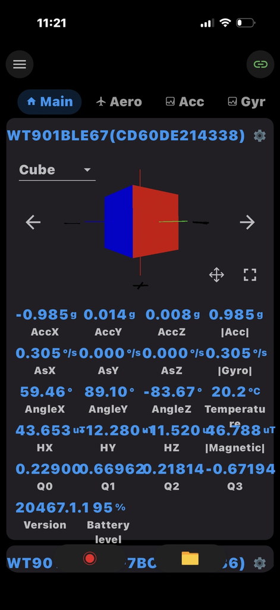

Circled: AccY 0.014 g · AccZ 0.008 g — both within ±0.02 g

ALIGNMENT COMPLETE

## The oar is level and the sensor is aligned.

Remove the supports only after the sensor is secure and both readings meet the target.

Review setup ↑